# Uncovering the Keys to being a Great Artist

Shahbaz Abdullah Magsi & Elise Deleon

2023-11-06

# Importing Libraries

```r
library(readr)
library(dplyr)
library(ggplot2)
library(gridExtra)
library(scales)
```

- readr: This is typically used for fast data reading, but in our project, base R’s read.csv() is actually used for data import.
- dplyr: We used this for data manipulation, such as calculating the number of songs per artist and organizing the data for analysis.
- ggplot2: We used this for creating visualizations to display the artist counts and streaming trends of the songs.
- gridExtra: We utilized this for arranging multiple ggplot2 visualizations in a single, organized grid for comparison.
- scales: We used this to format numerical data in our visualizations for better legibility and aesthetic presentation.

```r
data <- read.csv("spotify-2023.csv")
```

Data extracted from: Most Streamed Spotify Songs 2023 Nidula Elgiriyewithhana July 2023 https://www.kaggle.com/datasets/nelgiriyewithana/top-spotify-songs-2023/data

[figure not shown]

In the digital heartbeat of music, Spotify plays a pivotal role. Our project delves into the Top Artist’s remarkable resonance on the platform, seeking to understand the rhythm behind their songs’ popularity.

**Our Approach:** By tapping into Spotify’s rich data, we explore the melody of the top artist’s success, examining how their music’s characteristics harmonize with listener preferences.

**Methodology:** With user-friendly graphs and visual storytelling, we uncover patterns that reveal why the top artist’s tunes often top the charts.

**Insight and Impact:** For music insiders and fans alike (like us), our analysis offers a concise, data-driven narrative of what makes an artist stand out in the era of streaming.

# Question time!!!

[figure not shown]

In this project, we examine Spotify’s API data to analyze the factors behind the top artist’s presence in the top streams from 2010 to 2023. Our dataset is curated with the following key features:

- artist.s._name: Identifies the artist, crucial for tracking performance across songs.
- track_name: The song title, central to content analysis.
- streams: The play count, reflecting popularity.
- danceability_, energy_: Metrics representing a song’s rhythm and vigor.
- released_year, released_month: Timing of release, important for understanding trends and seasonal impacts.
- charts, playlist: Ranking how many playlists/songs an artist is in to understand the effects of how it correlates to popularity

This data will help us understand the qualities that have propelled the top artists’s music to the forefront of the digital music scene on Spotify.

# Pre-processing and Analysis:

In our exploration of Spotify’s musical landscape, we transformed a vast dataset into a concise narrative of what drives song success:

**Data Refinement**: We tidied up the dataset, discarding duplicates and standardizing data types to ensure clarity and accuracy.

**Selective Data**: We distilled the information from a complex 24 columns down to the most impactful ones, streamlining our analysis.

**Top Tracks Analysis**: Our gaze centered on the top 10 artists that had the most songs in the dataset, then focused on the top and the bottom of the 10.

**Engagement Insights**: Delving into streams and song features, we sought to understand the harmony between a track’s attributes and its popularity.

# WHO ARE THE TOP ARTISTS WITH MOST SONGS?

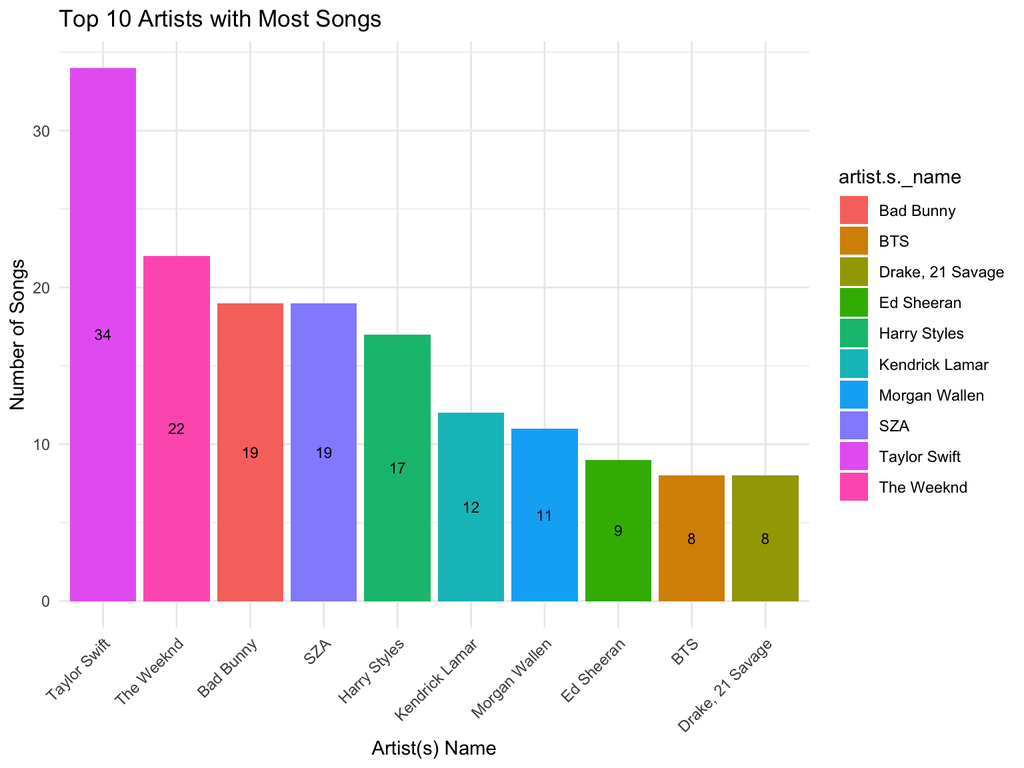

```r
artist_counts <- data %>%
  group_by(artist.s._name) %>%
  summarise(num_songs = n()) %>%
  arrange(desc(num_songs))

top_artists <- head(artist_counts, 10)

ggplot(top_artists, aes(x = reorder(artist.s._name, -num_songs), y = num_songs, fill = artist.s._name)) +
  geom_col() +
  geom_text(aes(label = num_songs), position = position_stack(vjust = 0.5), size = 3, color = 'black') +
  theme_minimal() +
  labs(x = 'Artist(s) Name', y = 'Number of Songs', title = 'Top 10 Artists with Most Songs') +
  theme(axis.text.x = element_text(angle = 45, hjust = 1))
```

It is clear to see that Taylor Swift dominates the charts with 34 songs, and Drake & 21 Savage have only 8 songs. Go swifties!!!

We chose to compare our top and bottom artists, Taylor Swift and Drake/21 Savage, to analyze **what it takes to hit the charts so many times!**

[figure not shown]

**What are the stream counts for each of their top 5 songs, and how significant are the differences in these counts?**

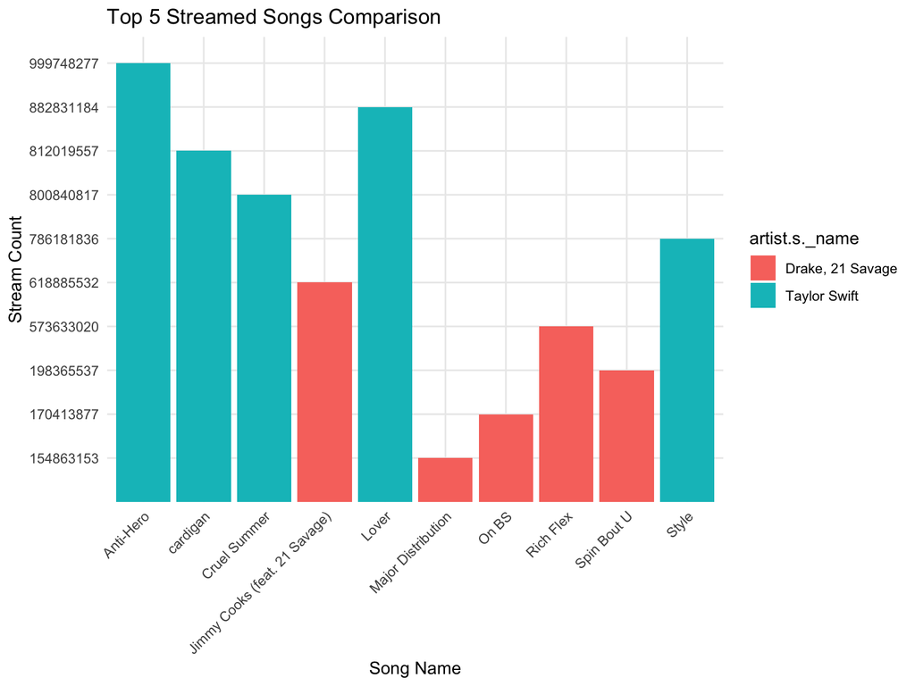

```r
selected_artists <- c("Taylor Swift", "Drake, 21 Savage")
selected_data <- data %>% filter(artist.s._name %in% selected_artists)

ranked_data <- selected_data %>%
  group_by(artist.s._name) %>%
  arrange(desc(streams)) %>%
  mutate(rank = row_number()) %>%
  filter(rank <= 5)

ggplot(ranked_data, aes(x = reorder(track_name, streams), y = streams, fill = artist.s._name)) +
  geom_col(position = "dodge") +
  theme_minimal() +
  labs(x = 'Song Name', y = 'Stream Count', title = 'Top 5 Streamed Songs Comparison') +
  theme(axis.text.x = element_text(angle = 45, hjust = 1))
```

# How does the difference appear when comparing Taylor Swift’s and Drake/21 Savage’s top-streamed song?

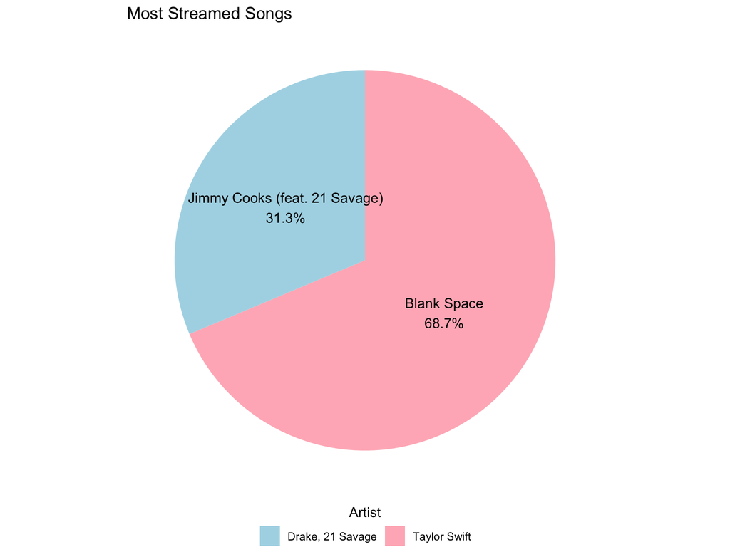

```r
selected_data <- data %>% filter(artist.s._name %in% c("Taylor Swift", "Drake, 21 Savage"))

selected_data$streams <- as.numeric(selected_data$streams)

most_streamed_taylor <- selected_data %>%
  filter(artist.s._name == "Taylor Swift") %>%
  arrange(desc(streams)) %>%
  slice_head(n = 1)

most_streamed_drake_21savage <- selected_data %>%
  filter(artist.s._name == "Drake, 21 Savage") %>%
  arrange(desc(streams)) %>%
  slice_head(n = 1)

combined_most_streamed <- bind_rows(most_streamed_taylor, most_streamed_drake_21savage)

total_streams <- sum(combined_most_streamed$streams)

combined_most_streamed <- combined_most_streamed %>%
  mutate(percentage = streams / total_streams * 100)

ggplot(combined_most_streamed, aes(x = "", y = percentage, fill = artist.s._name)) +
  geom_bar(stat = "identity", width = 1) +
  coord_polar("y") +
  theme_void() +
  labs(title = "Most Streamed Songs", fill = "Artist") +
  scale_fill_manual(values = c("Taylor Swift" = "light pink", "Drake, 21 Savage" = "light blue")) +
  theme(legend.position = "bottom") +
  guides(fill = guide_legend(ncol = 2, title.position = "top", title.hjust = 0.5)) +
  geom_text(aes(label = paste0(track_name, "\n", round(percentage, 1), "%")),
            position = position_stack(vjust = 0.5))
```

Our statistics show that 68.7% of listeners chose Taylor Swift’s ‘Blank Space’ over Drake and 21 Savage’s ‘Jimmy Cooks’, chosen by 31.3%, highlighting the disparity in stream counts.

# Do temporal changes in the year influence top song release?

```r
taylor_swift_data <- data %>%
  filter(artist.s._name == "Taylor Swift")

drake_21_data <- data %>%
  filter(artist.s._name == "Drake, 21 Savage")
```

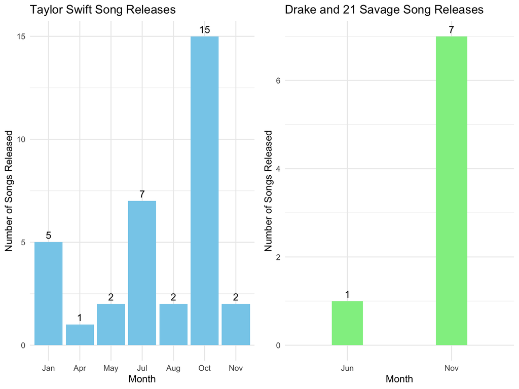

```r
plot_taylor_swift <- ggplot(taylor_swift_data, aes(x = factor(released_month, levels = 1:12, labels = c("Jan", "Feb", "Mar", "Apr", "May", "Jun", "Jul", "Aug", "Sep", "Oct", "Nov", "Dec")))) +
  geom_bar(fill = "skyblue") +
  geom_text(stat = 'count', aes(label = ..count..), vjust = -0.5) +
  labs(title = "Taylor Swift Song Releases",
       x = "Month",
       y = "Number of Songs Released") +
  theme_minimal()

plot_drake_21 <- ggplot(drake_21_data, aes(x = factor(released_month, levels = 1:12, labels = c("Jan", "Feb", "Mar", "Apr", "May", "Jun", "Jul", "Aug", "Sep", "Oct", "Nov", "Dec")))) +
  geom_bar(fill = "lightgreen", width = 0.3) +
  geom_text(stat = 'count', aes(label = ..count..), vjust = -0.5, position = position_dodge(width = 0.5)) +
  labs(title = "Drake and 21 Savage Song Releases",
       x = "Month",
       y = "Number of Songs Released") +
  theme_minimal()

grid.arrange(plot_taylor_swift, plot_drake_21, ncol = 2)
```

# Have stream trends for both artists changed over time?

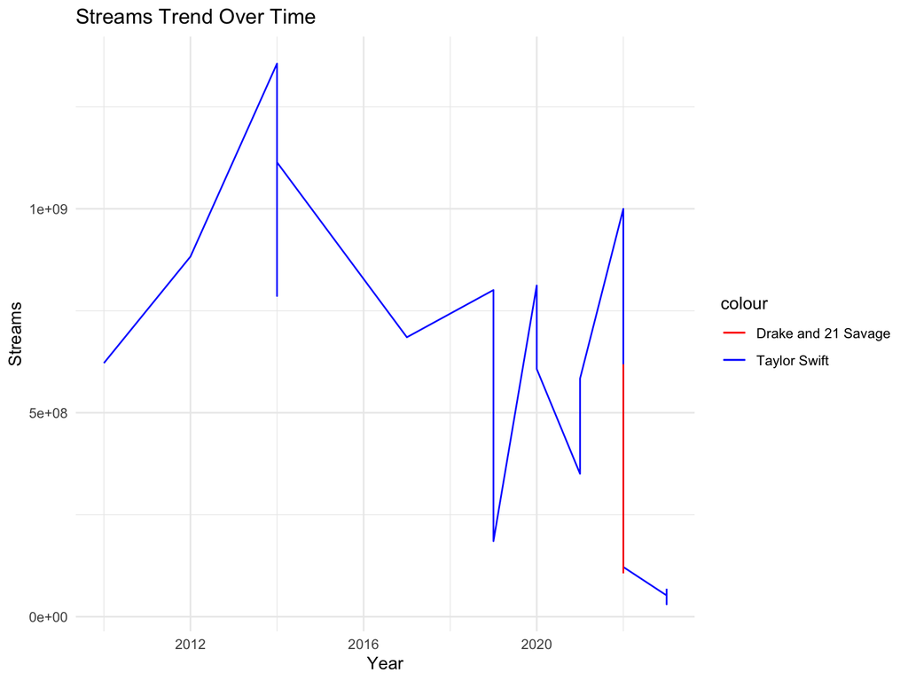

```r
taylor_swift_data$streams <- as.numeric(taylor_swift_data$streams)
drake_21_data$streams <- as.numeric(drake_21_data$streams)

ggplot() +
  geom_line(data = taylor_swift_data, aes(x = released_year, y = streams, group = 1, color = "Taylor Swift")) +
  geom_line(data = drake_21_data, aes(x = released_year, y = streams, group = 1, color = "Drake and 21 Savage")) +
  labs(title = "Streams Trend Over Time",
       x = "Year",
       y = "Streams") +
  theme_minimal() +
  scale_color_manual(values = c("Taylor Swift" = "blue", "Drake and 21 Savage" = "red"))
```

# Does higher dancebility in a song lead to a higher stream count?

[figure not shown]

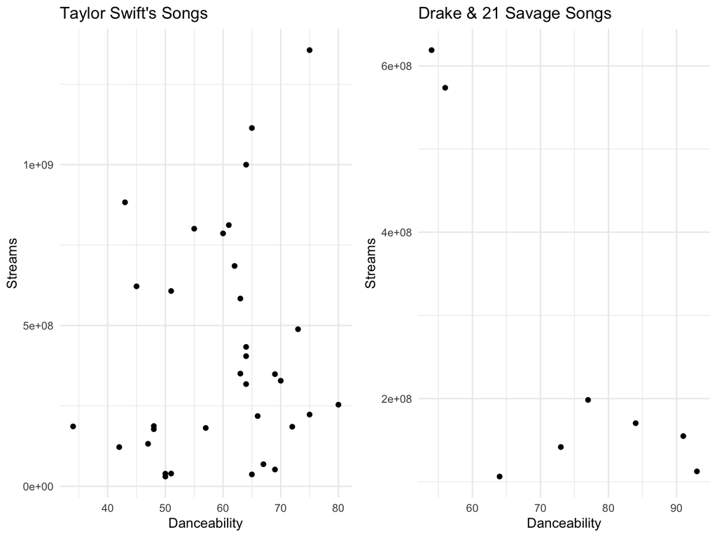

```r
plot_taylor_swift <- ggplot(taylor_swift_data, aes(x = danceability_., y = streams)) +
  geom_point() +
  labs(title = "Taylor Swift's Songs",
       x = "Danceability",
       y = "Streams") +
  theme_minimal()

plot_drake_21 <- ggplot(drake_21_data, aes(x = danceability_., y = streams)) +
  geom_point() +
  labs(title = "Drake & 21 Savage Songs",
       x = "Danceability",
       y = "Streams") +
  theme_minimal()

grid.arrange(plot_taylor_swift, plot_drake_21, ncol = 2)
```

Interestingly, not really! Having a higher danceability in a song does not necessarily correlate with higher stream counts; both Taylor Swift and Drake/21 Savage have songs with high danceability, yet Drake/21 Savage do not achieve the same streaming success as Taylor.

# Is there a correlation between valence/mood and danceability?

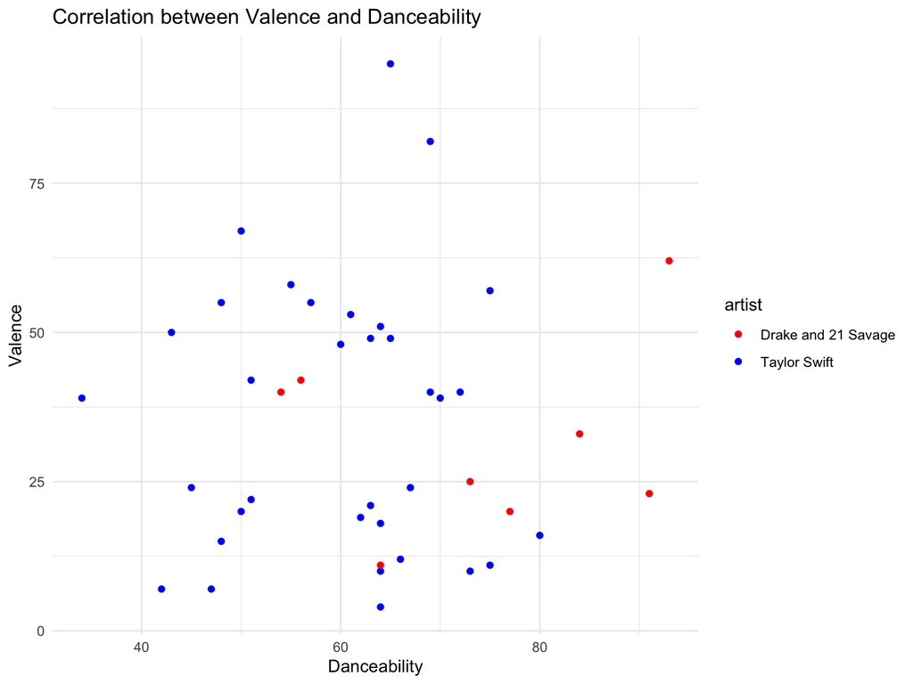

```r
taylor_swift_data$artist <- 'Taylor Swift'
drake_21_data$artist <- 'Drake and 21 Savage'

combined_data <- rbind(taylor_swift_data, drake_21_data)

ggplot(combined_data, aes(x = danceability_., y = valence_., color = artist)) +
  geom_point() +
  labs(title = "Correlation between Valence and Danceability",
       x = "Danceability",
       y = "Valence") +
  theme_minimal() +
  scale_color_manual(values = c("Taylor Swift" = "blue", "Drake and 21 Savage" = "red"))
```

On average, about 60% of Taylor’s tracks invite you to dance like no one’s watching! Ranging from 34% to a high of 80%, her songs offer a lil’ something for both wallflowers and dance floor divas.

# Does a higher energy level in a song lead to a higher stream count?

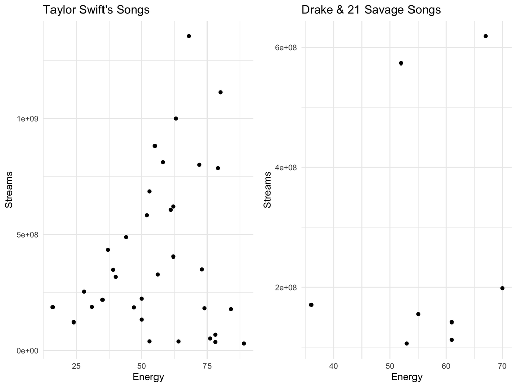

```r
plot_taylor_swift <- ggplot(taylor_swift_data, aes(x = energy_., y = streams)) +
  geom_point() +
  labs(title = "Taylor Swift's Songs",
       x = "Energy",
       y = "Streams") +
  theme_minimal()

plot_drake_21 <- ggplot(drake_21_data, aes(x = energy_., y = streams)) +
  geom_point() +
  labs(title = "Drake & 21 Savage Songs",
       x = "Energy",
       y = "Streams") +
  theme_minimal()

grid.arrange(plot_taylor_swift, plot_drake_21, ncol = 2)
```

Based on our analysis, a medium energy level in songs often lead to a higher stream count. Taylors songs are varied in energy, from melancholic to hype songs - theres something for everyone!

# Does the Beats Per Minute (BPM) influence a song’s likelihood of becoming a top hit?

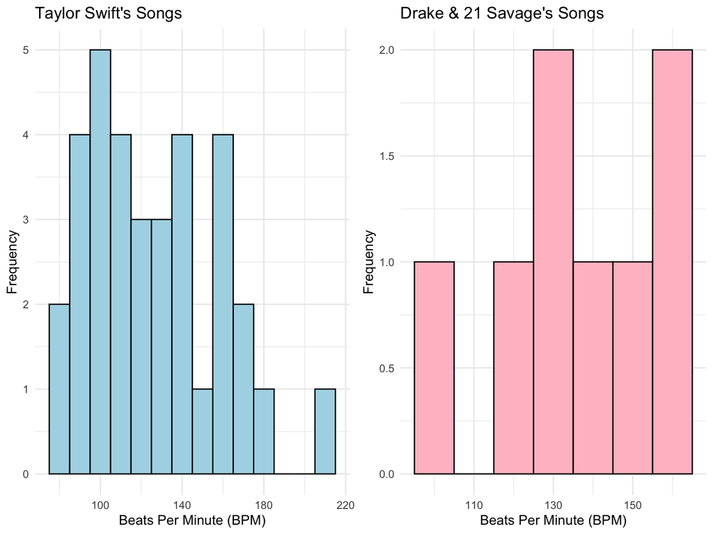

```r
plot_taylor_swift <- ggplot(taylor_swift_data, aes(x = bpm)) +
  geom_histogram(binwidth = 10, fill = "#ADD8E6", color = "black") +
  labs(title = "Taylor Swift's Songs",
       x = "Beats Per Minute (BPM)",
       y = "Frequency") +
  theme_minimal()

plot_drake_21 <- ggplot(drake_21_data, aes(x = bpm)) +
  geom_histogram(binwidth = 10, fill = "#FFC0CB", color = "black") +
  labs(title = "Drake & 21 Savage's Songs",
       x = "Beats Per Minute (BPM)",
       y = "Frequency") +
  theme_minimal()

grid.arrange(plot_taylor_swift, plot_drake_21, ncol = 2)
```

# Does featuring a top hit in a Spotify playlist correlate with increased stream counts?

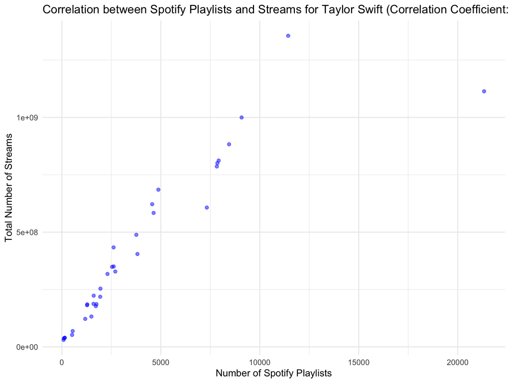

[figure not shown]

```r
correlation <- cor(taylor_swift_data$in_spotify_playlists, taylor_swift_data$streams)

ggplot(taylor_swift_data, aes(x = in_spotify_playlists, y = streams)) +
  geom_point(color = 'blue', alpha = 0.5) +
  labs(x = 'Number of Spotify Playlists', y = 'Total Number of Streams',
       title = paste('Correlation between Spotify Playlists and Streams for Taylor Swift (Correlation Coefficient:', round(correlation, 2), ')')) +
  theme_minimal()
```

As expected, the number of playlists a top hit is featured in tends to correlate with higher streaming numbers.

# SUMMMARY

The aim was to decipher the elements contributing to Taylor Swift’s dominance on Spotify’s streaming charts and how they compare with Drake/21 Savage’s performance.

We harnessed Spotify’s API data, focusing on a set of defined metrics such as song features, release timing, and playlist inclusion to analyze trends and patterns in song popularity.

Our analysis implies that versatility in music and strategic playlist placement may be key to streaming success. However, the research is limited to specific metrics and could be expanded to include broader factors for a more comprehensive understanding. Future analysis could benefit from including a wider array of artists and additional listener data to validate and extend these findings.